# Level1 - Geomを知る

## geom_count, geom_tile, geom_bin2d - 3軸グラフ または ヒートマップ

面内でグラフを書く以上、2軸が基本ですが、Rでは5軸まで可能です。が、実際解釈しやすいのは3軸までではないでしょうか。ということで3軸の書き方の例を紹介します。まずは geom_count から。縦軸、横軸ともに離散変数であることに留意してください。

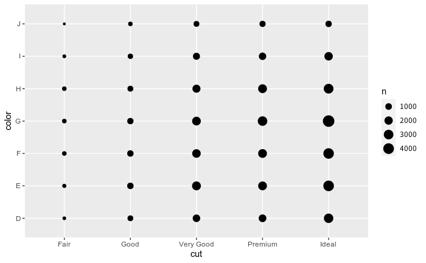

```r
# geom_count
ggplot(diamonds) +
  geom_count(aes(cut, color))
```

これは縦軸、横軸が離散変数で、マーカーの大きさによって数を表すグラフです。ちなみに、各点の具体的な数値は以下のコードで確認できます。cut が 5 水準、color が 7 水準あるので 35 個出てきます。今後説明する内容を含みますが、まだ理解できなくてもOKです。

```r
diamonds %>%
  count(cut, color)
```

| cut | color | n |
| --- | --- | --- |
| Fair | D | 163 |
| Fair | E | 224 |
| Fair | F | 312 |
| Fair | G | 314 |
| Fair | H | 303 |
| Fair | I | 175 |
| Fair | J | 119 |
| Good | D | 662 |
| Good | E | 933 |
| Good | F | 909 |

[output cut: 25 more lines]

次にヒートマップです。これ描けると何かそれっぽいです。上のコードを利用して各水準の組み合わせのカウントデータを色分けします。

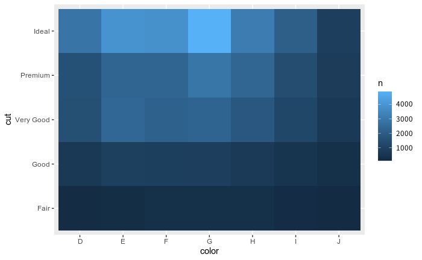

```r
diamonds %>%
  count(cut, color) %>%
  ggplot(aes(color, cut)) +
  geom_tile(aes(fill = n))
```

続いて、縦軸横軸が連続変数の場合は、geom_bin2d が使えます。

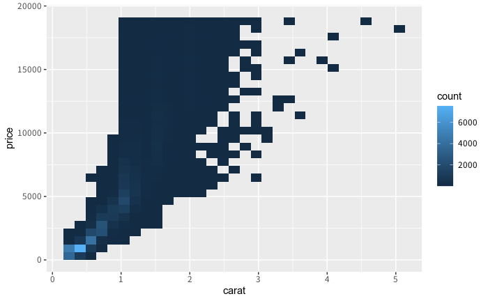

```r
ggplot(diamonds) +
  geom_bin2d(aes(carat, price))
```

色が見づらい、という場合は変更可能です。

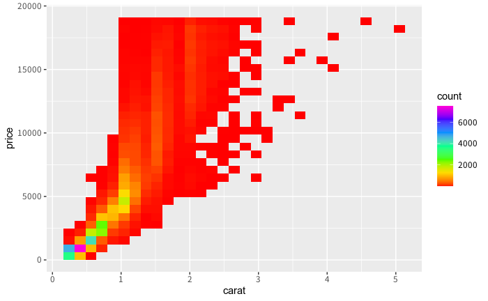

```r
ggplot(diamonds) +
  geom_bin2d(aes(carat, price)) +
  scale_fill_gradientn(colors = rainbow(7))
```

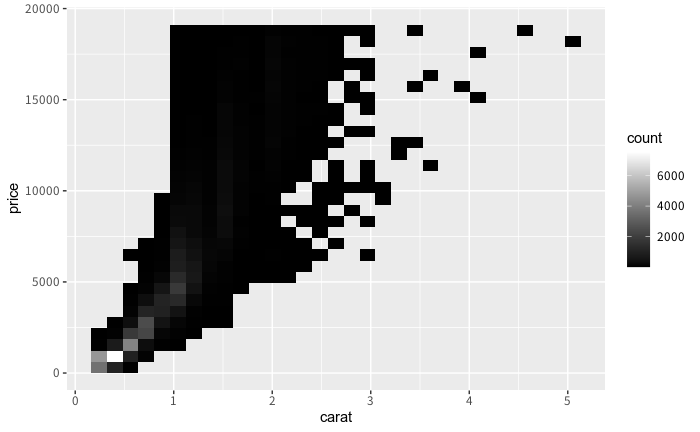

```r
ggplot(diamonds) +
  geom_bin2d(aes(carat, price)) +
  scale_fill_gradient(low = "black", high = "white")
```

色の指定方法はたくさんあるので、こんな色づけできる？と思ったらご質問ください。

ところでここまでの例は色付けをカウントデータにしていましたが、指定した変数で色付けすることも可能です。

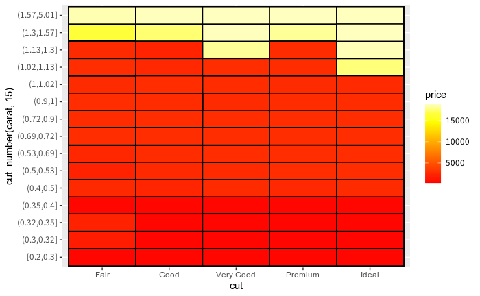

```r
ggplot(diamonds, aes(cut, cut_number(carat, 15), fill = price)) +
  geom_tile(col = "black", size = 0.5) +
  scale_fill_gradientn(colors =heat.colors(10))
```

今回使っているデータでは、ダイヤモンドの価格は cut の良し悪しにはあまり依存せず、ダイヤの大きさ carat の影響が大きいようです。  
なお、この例では、連続変数である carat を、cut_number で区分け数を指定して離散変数にしています。

## facet_wrap, facet_grid - 図を水準ごとに分けて描く

前項はマーカーの大きさや色によって軸を増やしましたが、もう一つの方法がファセットです。

- facet_wrap：1軸増やす
- facet_grid：2軸増やす

という使い分けです。

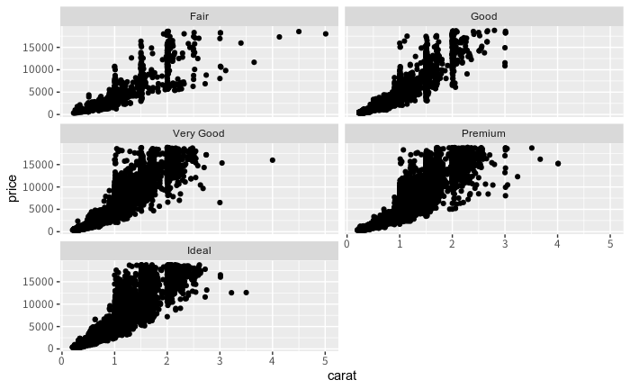

```r
# facet_wrap
ggplot(diamonds, aes(carat, price)) +
  geom_point() +
  facet_wrap(~cut, ncol = 2)
```

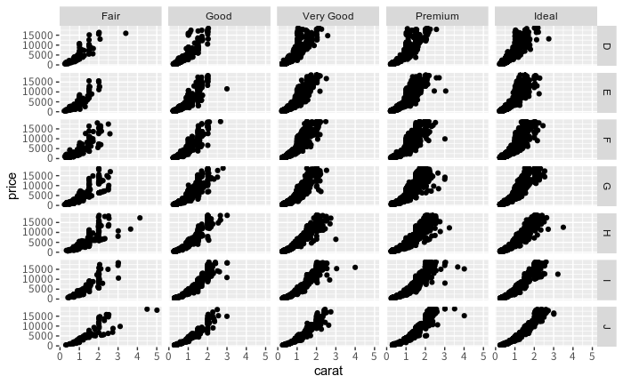

```r
# facet_grid
ggplot(diamonds, aes(carat, price)) +
  geom_point() +
  facet_grid(color~cut)
```

ちなみに color はダイヤの色で、Jが最悪、Dが最良の指標です。D の方が carat に対する価格の勾配が大きいようです。

## 練習問題

### 問題1：geom_pointとgeom_smooth

データセット：mpg について、次の図を描くのにトライしてみてください。

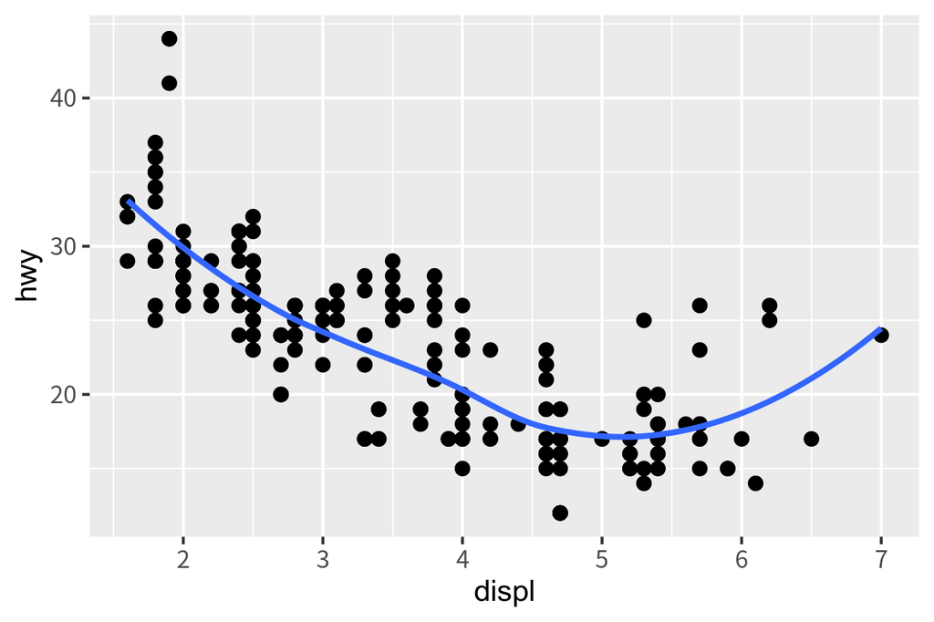

練習問題1-1

↑Shift + Clickで拡大図になります。

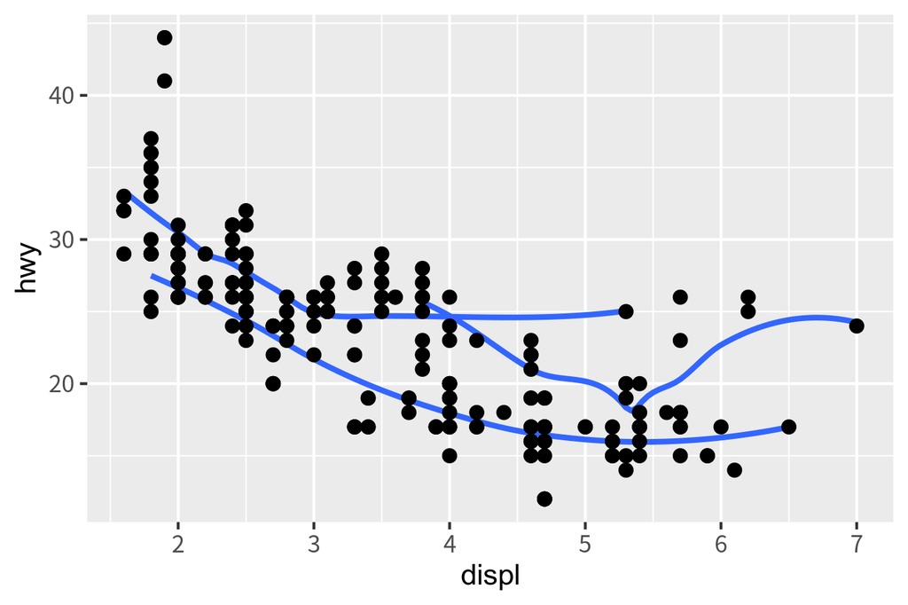

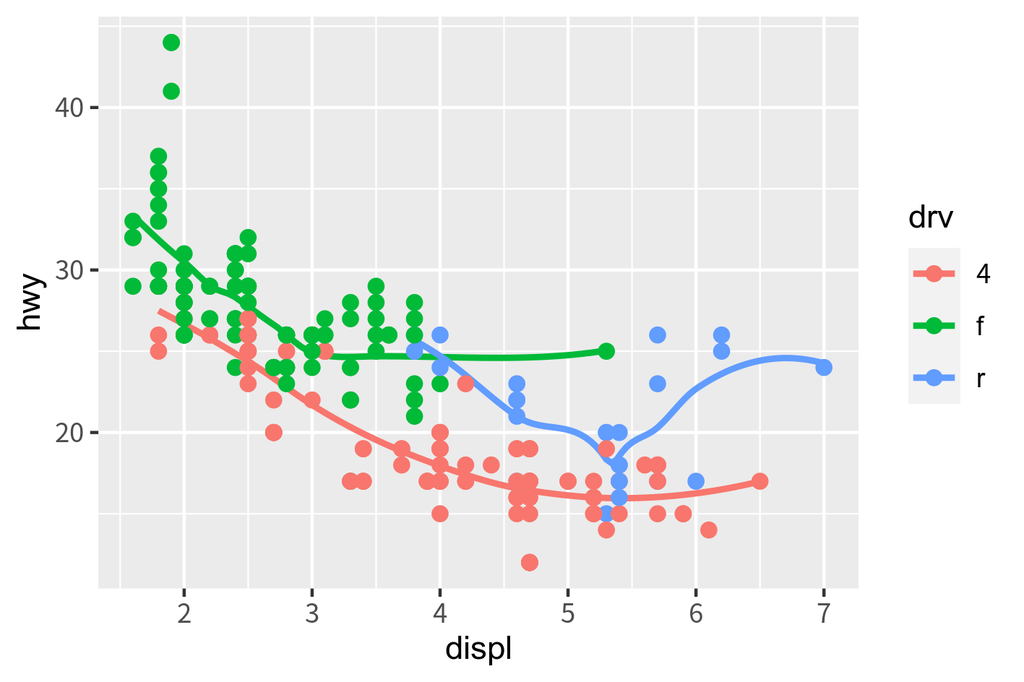

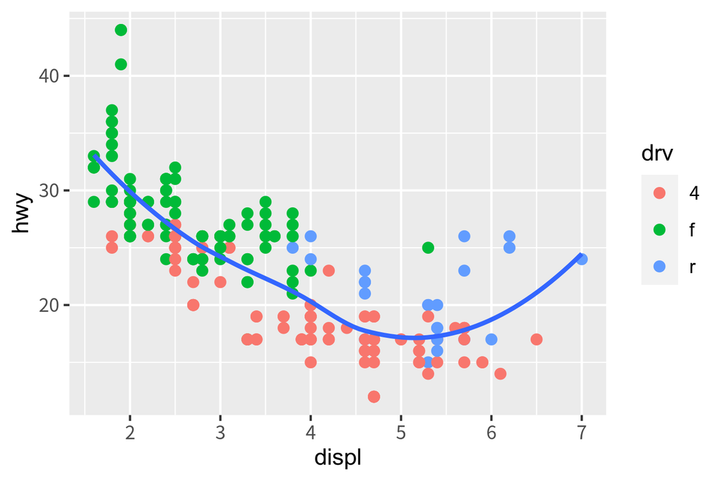

練習問題1-4

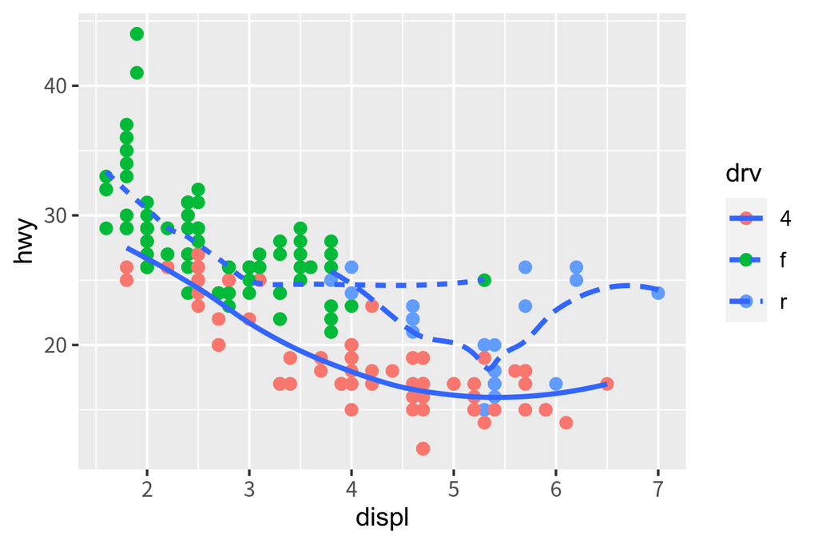

練習問題1-5

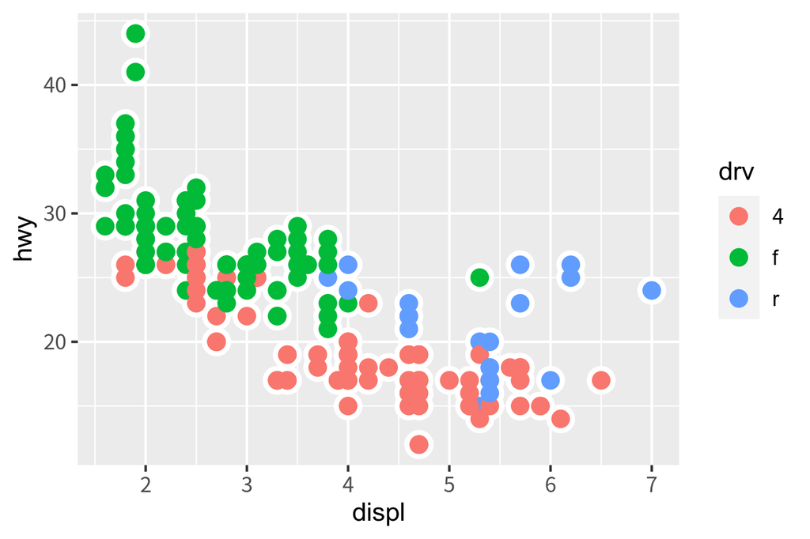

### 問題2：geom_boxplot

データセット：diamonds について、以下の問題にトライしてみましょう。

1. diamonds に含まれる変数はどんなものが含まれるか。
2. そのうち、離散変数は何か。
3. いずれかの離散変数に対して、price の箱ひげ図を描く。

### 問題3: geom_bar

データセット：mpg について、次の図を描くのにトライしてみてください。

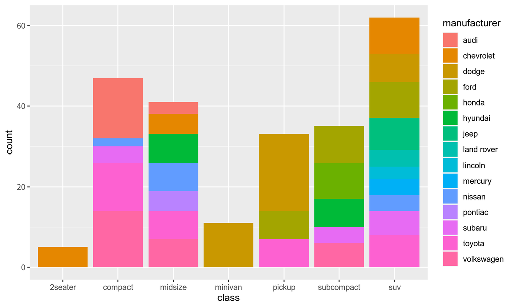

練習問題3-1

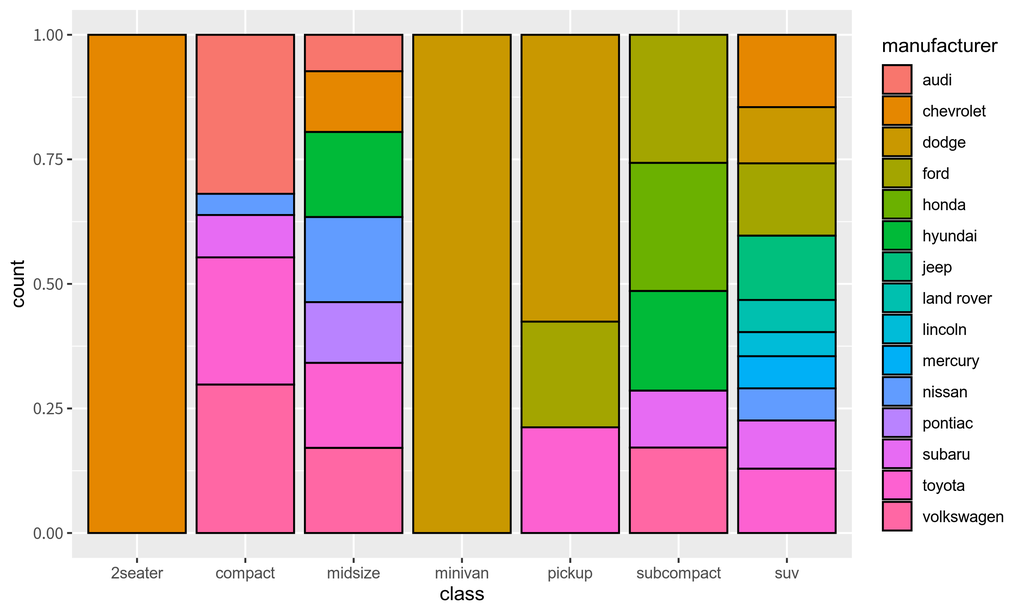

練習問題3-2

ヒント：黒い枠線は col = “black” で描けます。

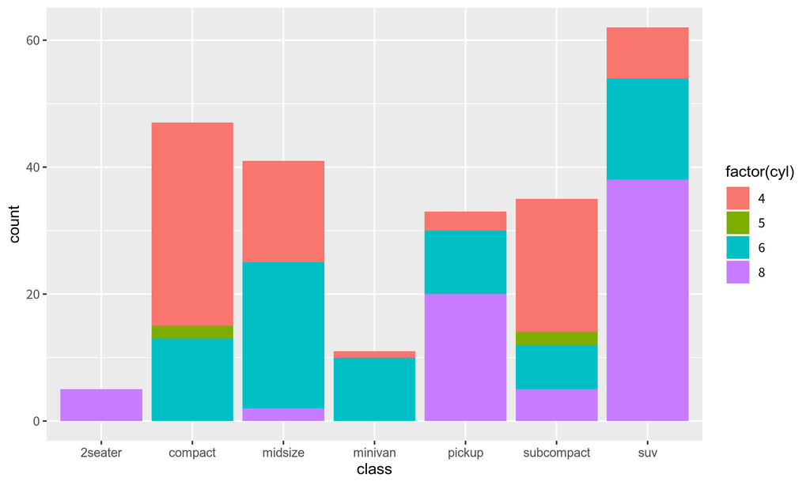

練習問題3-3

ヒント：cyl は連続変数のため、factor(cyl）とすることでファクタ（離散値）に変換できます。

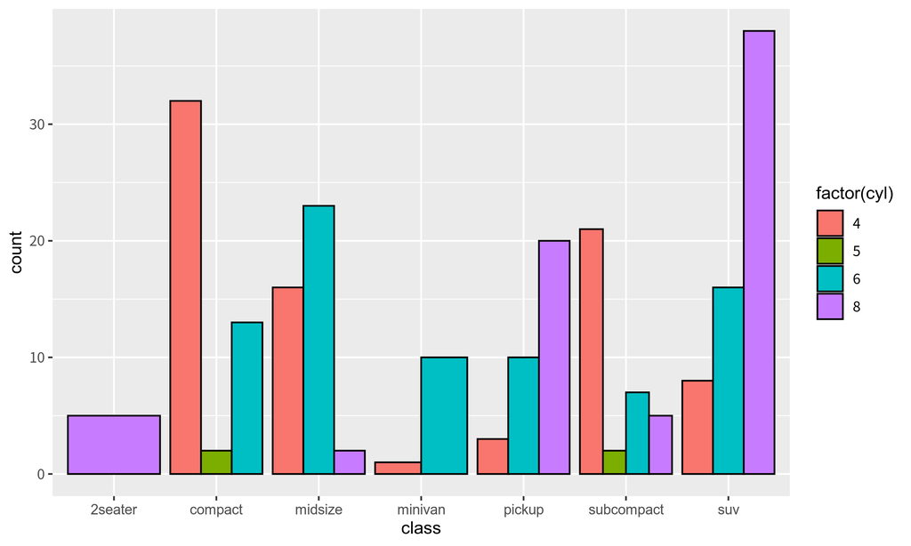

練習問題3-4

## 問題4 3軸グラフ

データセット mpg について、どんなものでも良いので 3軸グラフを描いてみましょう。  
自分が面白いと思う変数の組み合わせを探してみるのも良い練習になると思います。

## 問題5 ファセット

データセット mpg について、次の図を書いてみましょう。

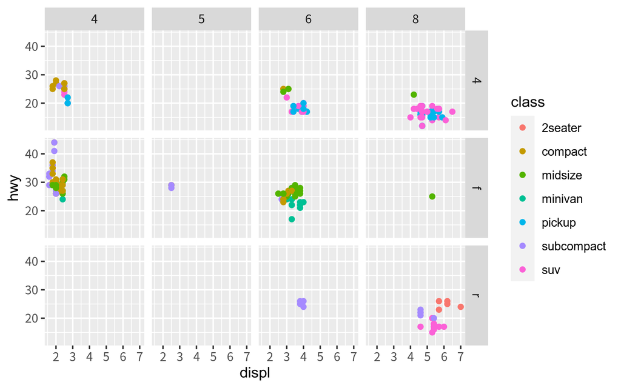

練習問題5

# 図を見やすくする

ここまでいろいろな geom を紹介してきましたが、図が見づらいと思う部分もあったと思います。そういう場合、いろいろなデコレーションをすることができます。ここでは以下の内容を紹介します。

- グラフ全体の体裁を変える
- 軸にタイトルをつける
- グラフにタイトルをつける
- グラフの文字の大きさを変える
- グラフの表示範囲を変更する
- グラフの目盛を変える
- 目盛線の体裁を変える
- 軸を入れ替える

ここでは、geom は以下のものを使い、使いまわしますので変数に代入しておきます。

```r
p <- ggplot(mpg, aes(displ, hwy, col = class)) +
  geom_point()
p
```

[output not shown]

## theme_** - グラフ全体の体裁を変える

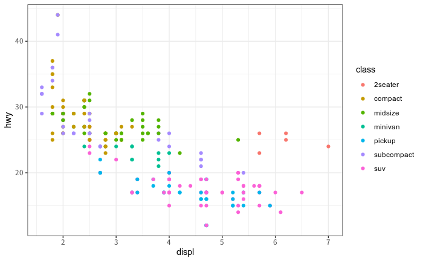

少し印象変わったのが分かるでしょうか。他のものも試してみてください。

## labs or scale ファミリー - 軸にタイトルをつける

デフォルトでは変数名が表示されますが、自由に変更できます。やり方は labs と scale ファミリーの2つがあります。簡単なのは labs です。

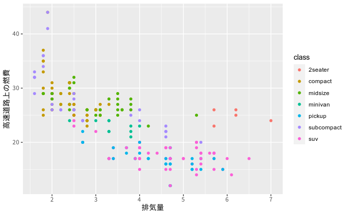

scale ファミリーはちょっと長いですが、軸の目盛りを変更するときなどに使うので、一緒に設定したいときに使ったりします。

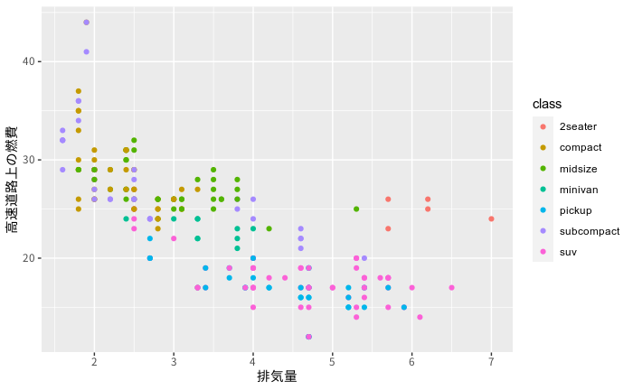

```r
p +
  scale_x_continuous(name = "排気量") +
  scale_y_continuous(name = "高速道路上の燃費")
```

```r
NA
```

labs, scale ファミリーともに、タイトルをダブルクォーテーションで囲うのを忘れずに。